# Evaluate decoy quality

Lieven Clement

# Data Import

## Load data

mzid files can be loade via de mzID function in the mzID package. Because we prefer to work with a the data in a table format we flatten the data. We show the first 6 rows of data.

```r
library(mzID)
dataFlat <- flatten(mzID("~/Downloads/SGA2019-data/identification/pyroUniprot.mzid"))
```

```
reading pyroUniprot.mzid... DONE!
```

```r
head(dataFlat)
```

```
   spectrumid   retention time
1  index=9160 3487.38460000002
2 index=11961        4590.0252
3 index=15158 6033.02170000002
4  index=3088 1426.66639999998
5  index=8361        3205.7502
6  index=1672         939.7677
                     spectrum title
1 1031.99536132813_3487.38460000002
2        1014.54040527344_4590.0252
3 555.353698730469_6033.02170000002
4   421.2587890625_1426.66639999998
5        773.912719726563_3205.7502
6         391.200592041016_939.7677
  acquisitionnum passthreshold rank
```

[output cut: 111 more lines]

## Column names

We will assess the names of the variables in the mzid file.

```r
names(dataFlat)
```

```
 [1] "spectrumid"
 [2] "retention time"
 [3] "spectrum title"
 [4] "acquisitionnum"
 [5] "passthreshold"
 [6] "rank"
 [7] "calculatedmasstocharge"
 [8] "experimentalmasstocharge"
 [9] "chargestate"
[10] "ms-gf:specevalue"
[11] "omssa:evalue"
[12] "peptideshaker psm confidence"
[13] "peptideshaker psm confidence type"
[14] "peptideshaker psm score"
[15] "x!tandem:expect"
[16] "theoretical mass"
[17] "isdecoy"
[18] "pre"
[19] "post"
[20] "start"
[21] "end"
[22] "accession"
[23] "description"
[24] "pepseq"
[25] "modified"
[26] "modification"
[27] "idFile"
[28] "spectrumFile"
[29] "databaseFile"
```

# Evaluate decoys

We would like to assess the decoy quality for the omssa and x!tandem scores. The scores are e-values. Small e-values are better. For visualisation purposes we transform the e-values by taking the -log10

## Omssa

### Preprocess mzid data

We first subset the data, because there are many missing values: PSMs without omssa score, and we remove the missing values. Next we -log10 transform the data.

```r
data <- dataFlat[,c("isdecoy","omssa:evalue")]
names(data) <- c("decoy","score")
data <- na.exclude(data)
data$score <- -log10(as.double(data$score))
```

### Histogram of targets and decoys

```r
library(ggplot2)
#We will use 50 breaks
nBreaks <- 50
binwidth <- diff(range(data$score))/nBreaks
print(binwidth)
```

```
[1] 6.096771
```

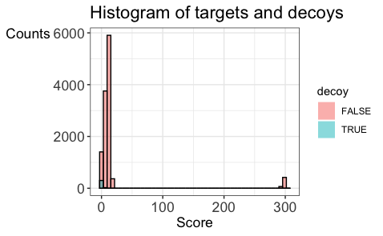

```r
      ggplot(data, aes(score, fill = decoy, col=I("black")))+ geom_histogram(alpha = 0.5, binwidth=binwidth, position = 'identity') +  labs(x = 'Score', y = 'Counts' ,title = 'Histogram of targets and decoys') +
  theme_bw() +
  theme(
    plot.title = element_text(size = rel(1.5)),
    axis.title = element_text(size = rel(1.2)),
    axis.text = element_text(size = rel(1.2)),
    axis.title.y = element_text(angle = 0))
```

### PPplot of targets and decoys

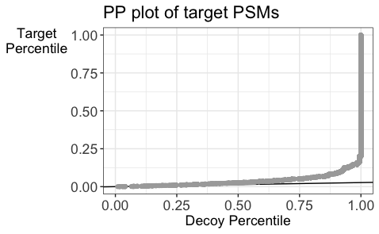

```r
library(dplyr)
pi0 <- sum(data$decoy)/sum(!data$decoy)
ppPlot <- ggplot()  +
geom_abline(slope = pi0,color = 'black') +
labs(x = 'Decoy Percentile', y = 'Target\nPercentile' ,title = 'PP plot of target PSMs') +
xlim(0,1) + ylim(0,1) +
theme_bw() +
theme(
   plot.title = element_text(size = rel(1.5)),
   axis.title = element_text(size = rel(1.2)),
   axis.text = element_text(size = rel(1.2)),
   axis.title.y = element_text(angle = 0))
x <- data$score[!data$decoy]
Ft <- ecdf(x)
Fd <- ecdf(data$score[data$decoy])
df <- data_frame(Fdp = Fd(x), Ftp = Ft(x))
ppPlot + geom_point(data = df,aes(Fdp,Ftp),color = 'dark grey')
```

## Xtandem

### Preprocess mzid data

```r
data <- dataFlat[,c("isdecoy","x!tandem:expect")]
names(data) <- c("decoy","score")
data <- na.exclude(data)
data$score <- -log10(as.double(data$score))
```

### Histogram of targets and decoys

```r
library(ggplot2)
#We will use 50 breaks
nBreaks <- 50
binwidth <- diff(range(data$score))/nBreaks
print(binwidth)
```

```
[1] 0.3679588
```

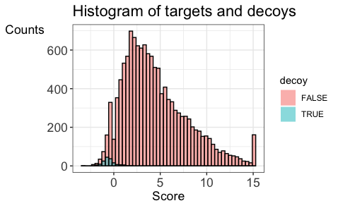

```r
      ggplot(data, aes(score, fill = decoy, col=I("black")))+ geom_histogram(alpha = 0.5, binwidth=binwidth, position = 'identity') +  labs(x = 'Score', y = 'Counts' ,title = 'Histogram of targets and decoys') +
  theme_bw() +
  theme(
    plot.title = element_text(size = rel(1.5)),
    axis.title = element_text(size = rel(1.2)),
    axis.text = element_text(size = rel(1.2)),
    axis.title.y = element_text(angle = 0))
```

### PPplot of targets and decoys

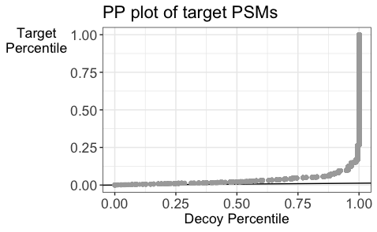

```r
library(dplyr)
pi0 <- sum(data$decoy)/sum(!data$decoy)
ppPlot <- ggplot()  +
geom_abline(slope = pi0,color = 'black') +
labs(x = 'Decoy Percentile', y = 'Target\nPercentile' ,title = 'PP plot of target PSMs') +
xlim(0,1) + ylim(0,1) +
theme_bw() +
theme(
   plot.title = element_text(size = rel(1.5)),
   axis.title = element_text(size = rel(1.2)),
   axis.text = element_text(size = rel(1.2)),
   axis.title.y = element_text(angle = 0))
x <- data$score[!data$decoy]
Ft <- ecdf(x)
Fd <- ecdf(data$score[data$decoy])
df <- data_frame(Fdp = Fd(x), Ftp = Ft(x))
ppPlot + geom_point(data = df,aes(Fdp,Ftp),color = 'dark grey')
```